# Reporte Analisis

#### Bibliotecas incluidas.

```r
library(FactoMineR)
library(rattle)
library(cluster)
```

#### Directorio y datos

Seleccionamos el directorio donde vamos a trabajar e importamos los datos.  
Incluimos las 6 palabras más repetidas en los tweets.

```r
setwd("C:/Users/Hillary/Documents/GitHub/analisis-de-redes-sociales-grupo-hej/data")
loadedObj <- load("C:/Users/Hillary/Documents/GitHub/analisis-de-redes-sociales-grupo-hej/data/preprocess.RData")
Datos=get(loadedObj)
head(Datos)
```

```
##     palabra repetida
## 1    cambio     1143
## 2     votar      882
## 3 venezuela      876
## 4      vota      735
## 5    unidad      503
## 6     vamos      478
```

#### Hash Table

```r
#Calculamos la cantidad de palabras para crear el hash table.
n<-length(Datos$palabra)
#Creamos un hash table, cuya finalidad es tener todo el dataframe numerico y asi poder aplicar PCA.
#Es decir cada palabra representa un numero. Ej: 1->votar, 2->chiabe, etc.
IDpalabra = array(1:n)
```

```r
#Creamos un nuevo dataframe con todos los valores numericos.
newDatos = data.frame(IDpalabra,Datos$repetida)
colnames(newDatos)[2] <- "repetida"
#Colocamos nombres a las filas
rownames(newDatos) <- Datos[,1]
```

#### Análisis de Componentes Principales

Dado que los datos que obtuvimos de Twitter ya limpiados y estandarizados son un conjunto de datos multidimensional,se decidió utilizar el Análisis de Componentes Principales para poder reducir las dimensiones del problema. Más adelante esta técnica de análisis nos permitira descubrir interrelaciones entre los datos y de acuerdo con los resultados, proponer los análisis estadísticos más apropiados.

```r
#Llamamos al metodo usando la funcion prcomp de stats
modelo = prcomp(newDatos)
summary(modelo)
```

```
## Importance of components:
##                              PC1      PC2
## Standard deviation     2275.7925 28.18208
## Proportion of Variance    0.9999  0.00015
## Cumulative Proportion     0.9999  1.00000
```

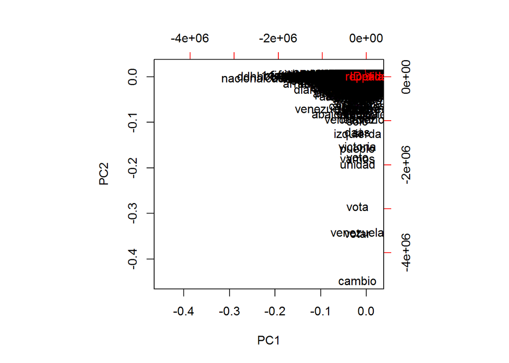

```r
biplot(modelo)
```

```r
#Aplicamos PCA
#Evaluar el valor del ncp.
suppressMessages(library(FactoMineR))
modelo <- PCA(newDatos, scale.unit = TRUE, ncp = 5, graph = FALSE)
#AUTOVALORES.
modelo$eig
```

```
##        eigenvalue percentage of variance cumulative percentage of variance
## comp 1  1.3349885               66.74943                          66.74943
## comp 2  0.6650115               33.25057                         100.00000
```

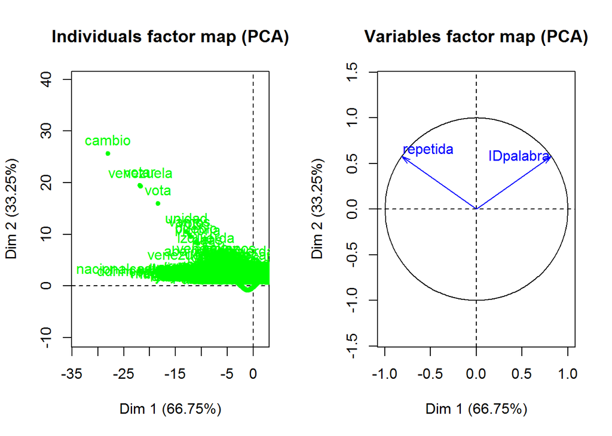

```r
#Graficamos el plano principal y el círculo de correlaciones por separado para las componentes principales 1 y 2
par(mfrow = c(1, 2)) # dividimos la pantalla para recibir dos gráficos.
plot(modelo, axes = c(1, 2), choix = "ind", col.ind = "green", new.plot = TRUE)
plot(modelo, axes = c(1, 2), choix = "var", col.var = "blue", new.plot = TRUE)
```

Un punto situado en el extremo de uno de los ejes, significa que ese individuo está muy relacionado con el respectivo componente.Palabras como “cambio” y “venezuela” tienen mayor contribución con “Dim 2”. Es decir, son más repetidas. Dos puntos que están muy cercanos en el plano, significa que ambos individuos tienen valores próximos en cada una de las respectivas variables.Se puede observar que aquellas palabras que se repiten una menor cantidad de veces se encuentran muy cercanas al eje (0,0).

Se aprecia que la relacion entre IDPalabra y repetidas es de menor grado o casi no se relacionan entre sí. Al graficar el plano principal obtenemos que a simple vista no se pueden distinguir los grupos, sin embargo basándonos en el resultado del círculo de correlación la cantidad de grupos posibles podría ser 2. Tambien tenemos valores atípicos como lo es “cambio”.

```r
# Cálculo de representatividad con los componentes 1 y 2
cos2.ind <- (modelo$ind$cos2[, 1] + modelo$ind$cos2[, 2]) * 100
```

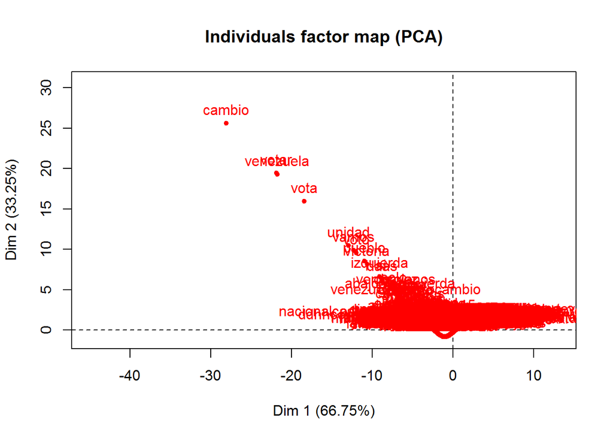

```r
# Gráfica los individuos que tengan cos2 >= 0.7 (70%)
par(mfrow = c(1, 1))
plot(modelo, axes = c(1, 2), choix = "ind", col.ind = "red", new.plot = TRUE, select = "cos2 0.7")
```

```r
# Cálculo de representatividad con los componentes 1 y 2
cos2.var <- (modelo$var$cos2[, 1] + modelo$var$cos2[, 2]) * 100
```

```r
#Se consideran mal representados los cos2 < 60%
cos2.var <- (modelo$var$cos2[, 1] + modelo$var$cos2[, 2]) * 100
```

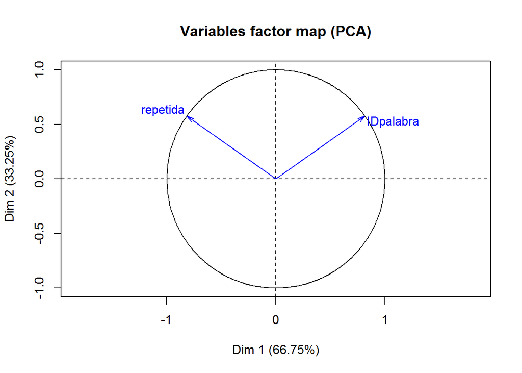

```r
# Grafica las variables que tengan cos2 >= 0.9 (90%)
plot(modelo, axes = c(1, 2), choix = "var", col.var = "blue", new.plot = TRUE, select = "cos2 0.9")
```

#### Clustering

```r
#Clustering sobre las componentes Principales
#Desplegar los cluster
res.hcpc <- HCPC(modelo, nb.clust = -1, consol = TRUE, min = 3, max = 3, graph = FALSE)
res.hcpc
res.hcpc$data.clust
```

Graficando los cluster con el árbol clasificador.

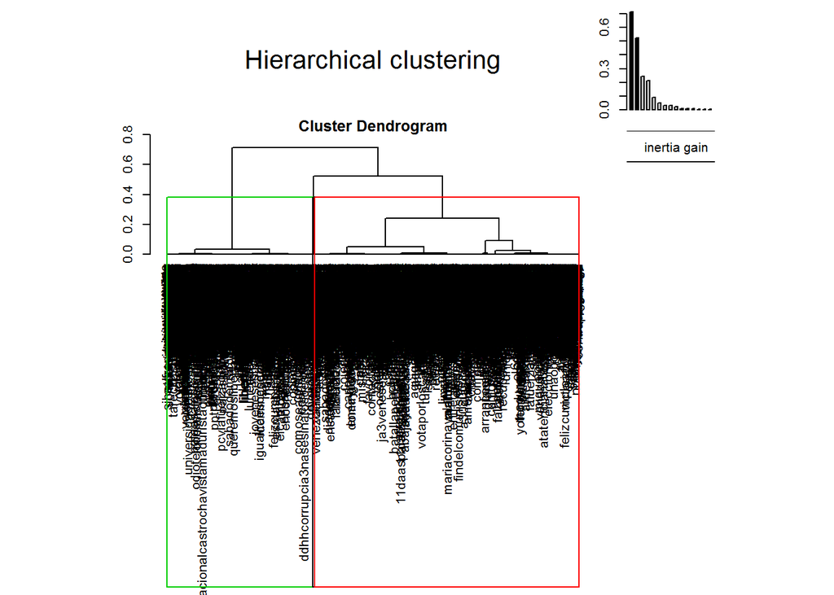

```r
plot(res.hcpc, axes=c(1,2), choice="tree", rect=TRUE,
     draw.tree=TRUE, ind.names=TRUE, t.level="all", title=NULL,
     new.plot=FALSE, max.plot=15, tree.barplot=TRUE,
     centers.plot=FALSE)
```

Graficando los cluster con el árbol clasificador en 3D.  
Aquí se observa con mayor facilidad la existencia de 3 grupos, la cual es la cantidad óptima de grupos para reprentar

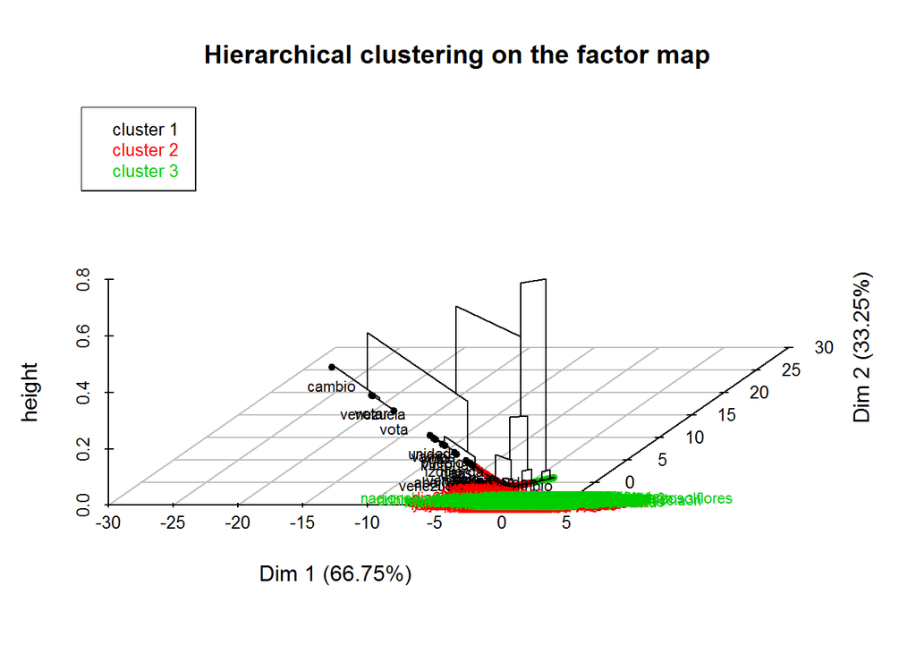

```r
plot(res.hcpc, axes=c(1,2), choice="3D.map", rect=TRUE,
     draw.tree=TRUE, ind.names=TRUE, t.level="all", title=NULL,
     new.plot=FALSE, max.plot=15, tree.barplot=TRUE,
     centers.plot=FALSE)
```

#### Clasificación Jerárquica Ascendente

Para poder hacer analisis utilizamos una muestra menor.

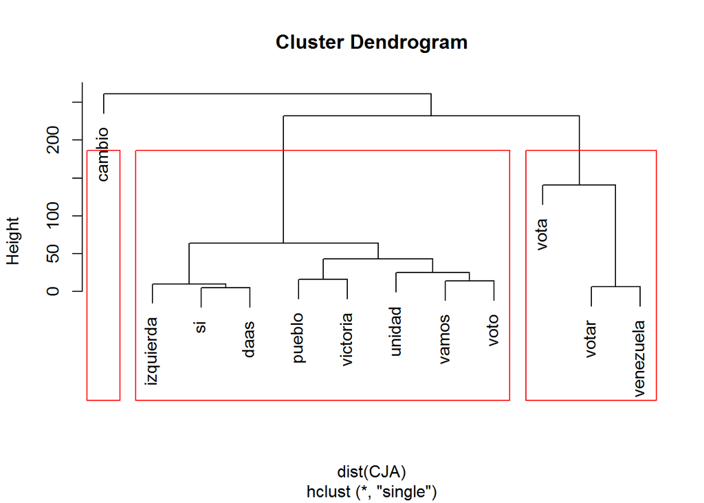

```r
CJA <- subset(newDatos, newDatos$repetida > 300)
#Usando la agregación del salto mínimo
modelo = hclust(dist(CJA), method = "single")
#Resaltamos en rojo los grupos.
plot(modelo)
rect.hclust(modelo, k = 3, border = "red")
```

Le asignamos un grupo a cada palabra.

```r
Grupo <- cutree(modelo, k = 3)
NDatos <- cbind(CJA, Grupo)
```

Mostramos los centros de cada clasificación.

```r
centros <- centers.hclust(CJA, modelo, nclust = 3, use.median = FALSE)
centros
```

```
##      IDpalabra repetida
## [1,]       1.0 1143.000
## [2,]       3.0  831.000
## [3,]       8.5  408.625
```

Gráfica de los centro para el cluster 1.

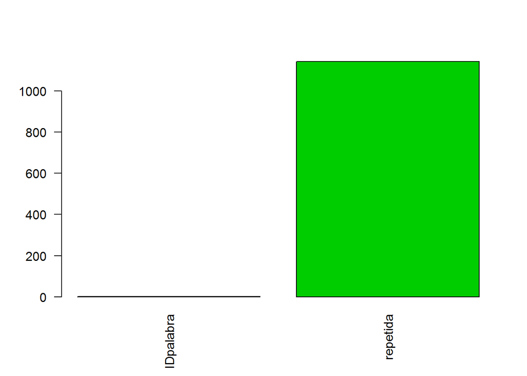

```r
rownames(centros) <- c("Cluster 1", "Cluster 2", "Cluster 3")
barplot(centros[1, ], col = c(2, 3, 4, 5, 6, 7), las = 2)
```

Gráfica de los centro para el cluster 2.

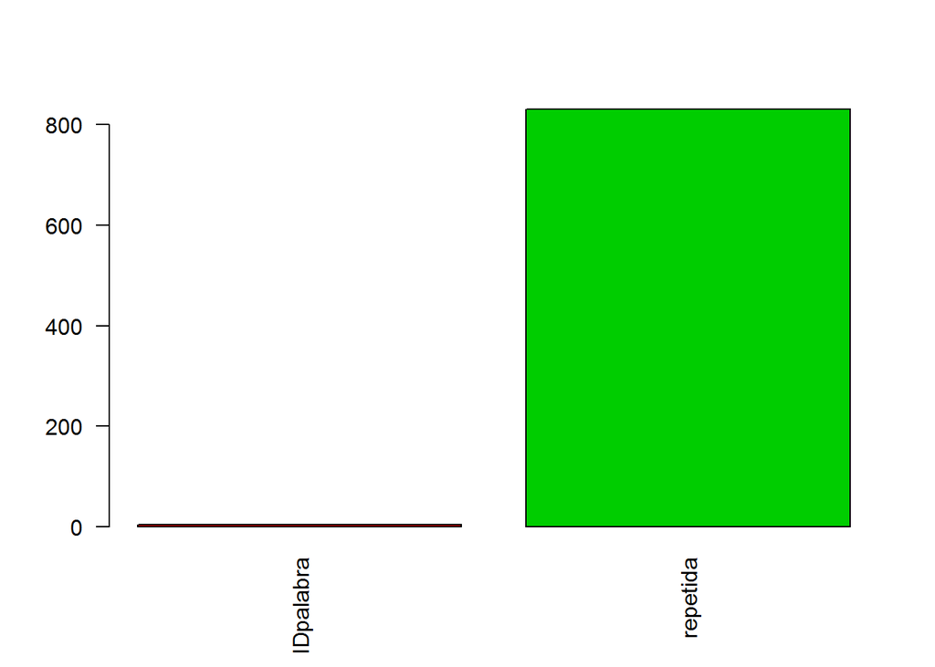

```r
barplot(centros[2, ], col = c(2, 3, 4, 5, 6, 7), las = 2)
```

Gráfica de los centro para el cluster 3.

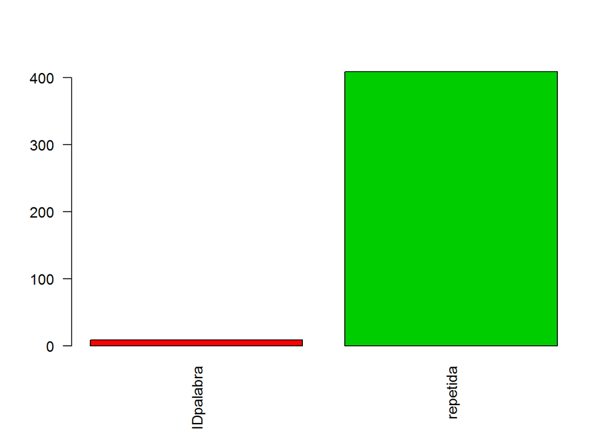

```r
barplot(centros[3, ], col = c(2, 3, 4, 5, 6, 7), las = 2)
```

Gráfica de los centro para todos clusters.

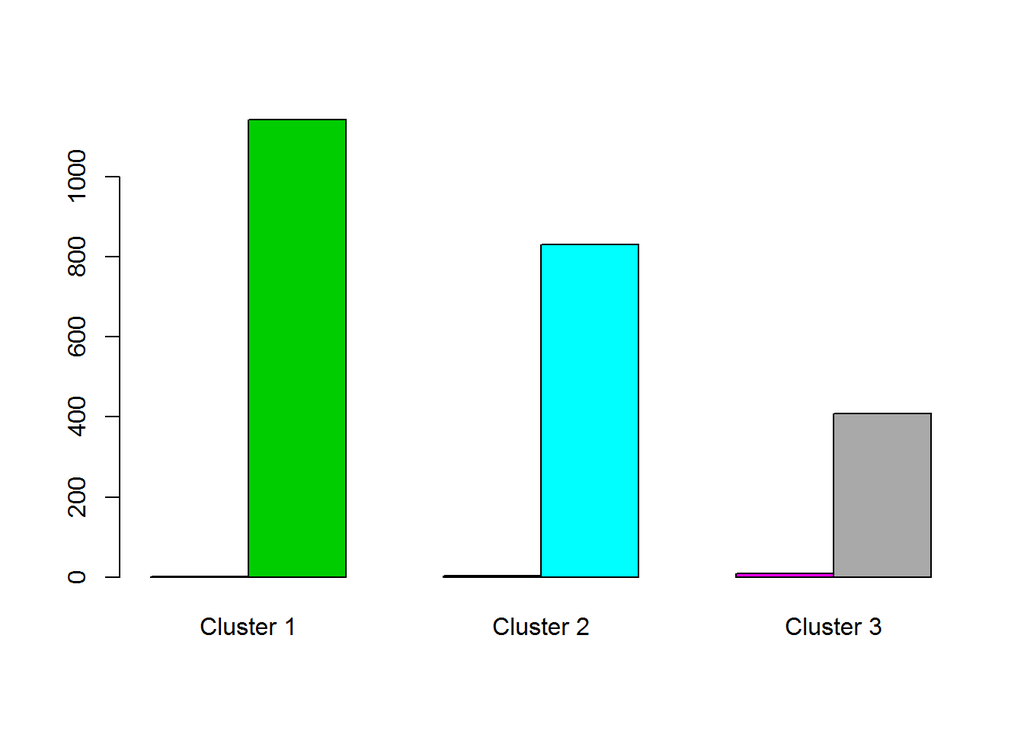

```r
barplot(t(centros), beside = TRUE, col = c(2, 3, 4, 5, 6, 7))
```

#### K-medias

Se procederá a buscar patrones en los datos usando la técnica de k-means para separar los datos en clústeres (grupos), con colores diferentes para cada grupo y su centroide, en nuestro caso particular el patrón es la frecuencia con la cual se repite, y luego poder agregarlos a un data frame a cada registro correspondiente.

Aplicaremos Codo de Jambu para seleccionar el K

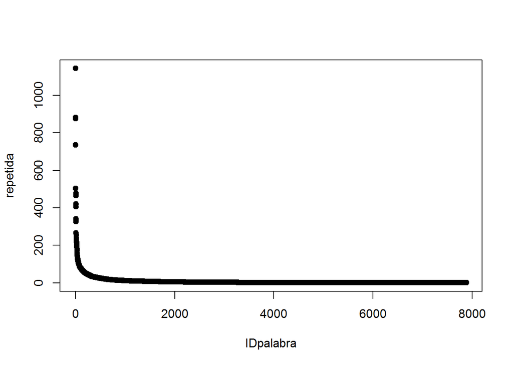

```r
plot(newDatos, pch = 19)
```

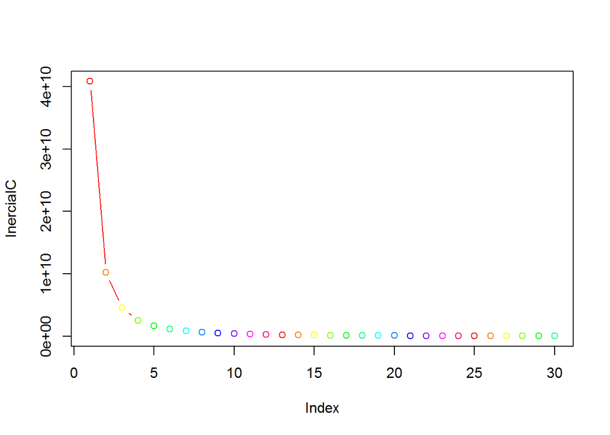

```r
InerciaIC = rep(0, 30)
for (k in 1:30) {
  grupos = kmeans(newDatos, k)
  InerciaIC[k] = grupos$tot.withinss
}
plot(InerciaIC, col = rainbow(12), type = "b")
```

Podemos observar que aparentemente hay 3 grupos utilizando un conjuntos de palabras.

```r
grupos <- kmeans(newDatos,3, iter.max = 100)

grupos
grupos$cluster
grupos$centers
grupos$totss  # Inercia Total
grupos$withinss  # Inercia Intra-clases por grupo (una para cada grupo)
grupos$tot.withinss  # Inercia Intra-clases
grupos$betweenss  # inercia Inter-clases
# Verificación del Teorema de Fisher
grupos$totss == grupos$tot.withinss + grupos$betweenss
grupos$size  # Tamaño de las clases
```

En el siguiente plot podemos observar los centroides y los distintos grupos.

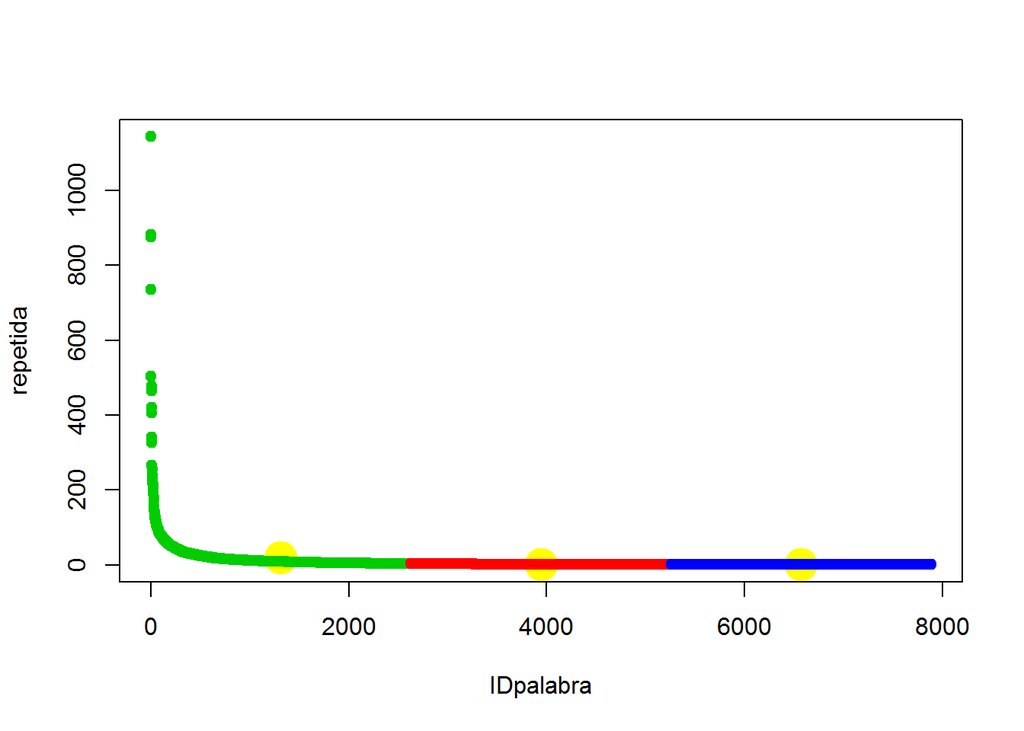

```r
plot(newDatos,pch = 19)
points(grupos$centers, pch = 19, col = "yellow", cex = 3)
points(newDatos, col = grupos$cluster + 1, pch = 19)
```

A continuación podemos se observa la interpretacion de los cluster por la comparación de sus centros .

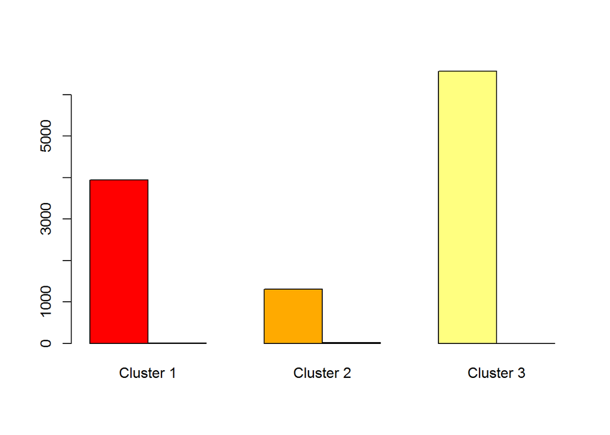

```r
rownames(grupos$centers) <- c("Cluster 1", "Cluster 2", "Cluster 3")
barplot(t(grupos$centers), beside = TRUE, col = heat.colors(5))
```

```r
NDatos <- cbind(newDatos, Grupo = grupos$cluster)
head(NDatos)
```

```
##           IDpalabra repetida Grupo
## cambio            1     1143     2
## votar             2      882     2
## venezuela         3      876     2
## vota              4      735     2
## unidad            5      503     2
## vamos             6      478     2
```